# Random Forest Classification(随机森林分类)

## 测试集独立验证

如果第一地点数据量足够大，可以取出1/2到1/3进行同一地点的独立验证。方法相同。

筛选测序集样品

```r
# metadata_test = subset(metadata, soiltype %in% c("H"))
# summary(metadata_test)
# idx = rownames(metadata_test) %in% colnames(table)
# metadata_test = metadata_test[idx,]
# otu_sub = table[,rownames(metadata_test)]

# metadata_test = subset(metadata_f, Site_1 %in% c("E"))
# summary(metadata_test)
# idx = rownames(metadata_test) %in% colnames(table)
# metadata_test = metadata_test[idx,]
# otu_sub2 = table[,rownames(metadata_test)]

# idx3 = sample(1:123, size = 67, replace = F)
# 注size=67，66比较小
# 选择的样本标记为TRUE，未选择的为FALSE
# idx3 = 1:123 %in% idx3
# idx2 = sample(1:123, size = 60, replace = F)
# # 选择的样本标记为TRUE，未选择的为FALSE
# idx2 = 1:123 %in% idx2

test = train[!idx3,]
test
```

|  | Filename | Group_day | Group_day1 | Group_dayE | Group | StateSite | StateSite_1 | State | Site | Site_1 | Day | Day_num | Day1 | DayE | Individual |
| --- | --- | --- | --- | --- | --- | --- | --- | --- | --- | --- | --- | --- | --- | --- | --- |
| HS00P004 | S3d0 | HS00 | HSpre | HSpre | HSP004 | HS | HS | H | S | S | 0 | 0 | pre | pre | P004 |
| HS00P010 | SEd0 | HS00 | HSpre | HSpre | HSP010 | HS | HS | H | S | S | 0 | 0 | pre | pre | P010 |
| HS00P019 | S11d0 | HS00 | HSpre | HSpre | HSP019 | HS | HS | H | S | S | 0 | 0 | pre | pre | P019 |
| HS00P029 | S21d0 | HS00 | HSpre | HSpre | HSP029 | HS | HS | H | S | S | 0 | 0 | pre | pre | P029 |
| DS00P030 | S22d0 | DS00 | DSpre | DSpre | DSP030 | DS | DS | D | S | S | 0 | 0 | pre | pre | P030 |
| HS00P031 | S23d0 | HS00 | HSpre | HSpre | HSP031 | HS | HS | H | S | S | 0 | 0 | pre | pre | P031 |
| DS00P037 | S28d0 | DS00 | DSpre | DSpre | DSP037 | DS | DS | D | S | S | 0 | 0 | pre | pre | P037 |
| HS00P040 | S31d0 | HS00 | HSpre | HSpre | HSP040 | HS | HS | H | S | S | 0 | 0 | pre | pre | P040 |
| HS00P041 | S32d0 | HS00 | HSpre | HSpre | HSP041 | HS | HS | H | S | S | 0 | 0 | pre | pre | P041 |
| HS00P042 | S33d0 | HS00 | HSpre | HSpre | HSP042 | HS | HS | H | S | S | 0 | 0 | pre | pre | P042 |

[output cut: 24 more lines]

```r
#test = metadata_f[!idx3,]
metadata_test = test
summary(metadata_test)
```

```
##    Filename          Group_day          Group_day1         Group_dayE
##  Length:34          Length:34          Length:34          Length:34
##  Class :character   Class :character   Class :character   Class :character
##  Mode  :character   Mode  :character   Mode  :character   Mode  :character
##
##
##
##     Group            StateSite         StateSite_1        State
##  Length:34          Length:34          Length:34          D: 9
##  Class :character   Class :character   Class :character   H:25
##  Mode  :character   Mode  :character   Mode  :character
##
##
##
##      Site              Site_1               Day       Day_num
##  Length:34          Length:34          Min.   :0   Min.   :0
##  Class :character   Class :character   1st Qu.:0   1st Qu.:0
##  Mode  :character   Mode  :character   Median :0   Median :0
##                                        Mean   :0   Mean   :0
##                                        3rd Qu.:0   3rd Qu.:0
##                                        Max.   :0   Max.   :0
##      Day1               DayE            Individual
##  Length:34          Length:34          Length:34
##  Class :character   Class :character   Class :character
##  Mode  :character   Mode  :character   Mode  :character
##
##
##
```

```r
idx4 = rownames(metadata_test) %in% colnames(table)
metadata_test = metadata_test[idx4,]
otu_sub2 = table[,rownames(metadata_test)]



# 转置，并添加分组信息
otutab_t2 = as.data.frame(t(otu_sub2))
otutab_t2$State = metadata_test[rownames(otutab_t2),]$State
```

基于训练集随机森林模型验证

```r
set.seed(315)
otutab.pred = predict(rf3, t(otu_sub2) )
pre_tab = table(observed=otutab_t2[,"State"],
                predicted=otutab.pred)
pre_tab
```

```
##         predicted
## observed  D  H
##        D  3  6
##        H  4 21
```

```r
# for (i in 0:30){
#    set.seed(i)
#    otutab.pred = predict(rf3, t(otu_sub2) )
#    pre_tab = table(observed=otutab_t2[,"State"],
#                 predicted=otutab.pred)
#    print(pre_tab)
# }
```

可视化验证结果

```r
# 整理样本原始分组和预测分类
predict = data.frame(group = otutab_t2[,"State"], predicted=otutab.pred)

# 保存预测结果表
write.table("SampleID\t", file=prediction_filename,append = F, quote = F, eol = "", row.names = F, col.names = F)
write.table(predict, file = prediction_filename,append = T, quote = F, row.names = T, col.names = T, sep = "\t")
# 转换为数值可视化
# 预测准确标为1，错误标为0
predict$result = ifelse(predict$group == predict$predicted, 1, 0)
# IND=1, TEJ=2
predict$predict = ifelse(predict$predicted == State_B, 1, 2)
# Set sample number in each row
column = 5

AA1 = predict[predict$group==State_B,]$predict
length(AA1)
```

```
## [1] 9
```

```r
row = round(length(AA1)/column + 0.5)
row
```

```
## [1] 2
```

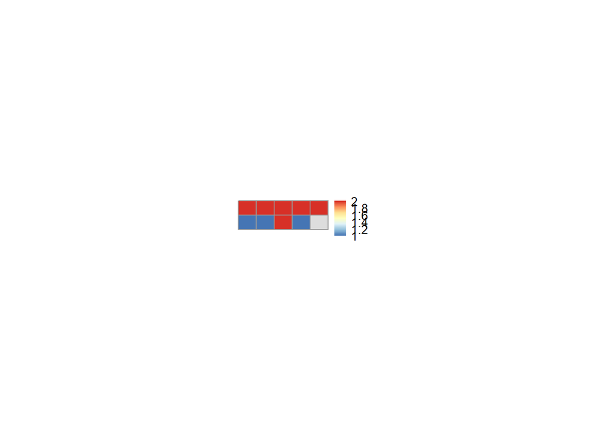

```r
i = column * row - length(AA1)
AA1 = c(AA1, rep(NA, i))
matrix1 = matrix(AA1, nrow = row, ncol = column, byrow = T)
pheatmap(matrix1, cluster_rows = F, cluster_cols = F, cellwidth = 15, cellheight = 12)
```

```r
#pheatmap(matrix1, cluster_rows = F, cluster_cols = F, cellwidth = 15, cellheight = 12,filename = "family_test_DD.pdf")
pheatmap(matrix1, cluster_rows = F, cluster_cols = F, cellwidth = 18, cellheight = 18,filename = testfilename1)
# Draw TEJ prediction result
BB1 = predict[predict$group==State_A,]$predict
length(BB1)
```

```
## [1] 25
```

```r
row = round(length(BB1)/column + 0.5)
i = column * row - length(BB1)
BB1 = c(BB1, rep(NA, i))
matrix2 = matrix(BB1, nrow = row, ncol = column, byrow = T)
pheatmap(matrix2, cluster_rows = F, cluster_cols = F, cellwidth = 15, cellheight = 12)
# 保存图片
#pheatmap(matrix2, cluster_rows = F, cluster_cols = F, cellwidth = 18, cellheight = 18, filename = "family_test_HH.pdf")
pheatmap(matrix2, cluster_rows = F, cluster_cols = F, cellwidth = 18, cellheight = 18, filename = testfilename2)



## 将生成的文件放入指定文件夹
tarDir <- result_file_names
dir.create(tarDir)
# 选取含特定字符创的文件（本例选取后缀为csv的所有文件）
tobeCopy1 <- list.files(".", pattern="*_rf.txt")
tobeCopy2 <- list.files(".", pattern="*_rf.pdf")
# 复制选中文件
sapply(tobeCopy1,function(x){file.copy(paste(".",x,sep="/"),tarDir,overwrite = TRUE)})
```

[output not shown]

```
##        importance_pre_pre_H_D_rf.txt prediction_binary_pre_pre_H_D_rf.txt
##                                 TRUE                                 TRUE
##              rfcv_pre_pre_H_D_rf.txt      sub_metadata_pre_pre_H_D_rf.txt
##                                 TRUE                                 TRUE
```

```r
sapply(tobeCopy2,function(x){file.copy(paste(".",x,sep="/"),tarDir,overwrite = TRUE)})
```

```
##    family_test_pre_pre_D_rf.pdf    family_test_pre_pre_H_rf.pdf
##                            TRUE                            TRUE
##         rfcv_pre_pre_H_D_rf.pdf top_feautres_pre_pre_H_D_rf.pdf
##                            TRUE                            TRUE
```

```r
# 删除转移过的文件
allfile = dir()
txtfile1 <- grep("*_rf.txt",allfile)
txtfile2 <- grep("*_rf.pdf",allfile)
file.remove(allfile[txtfile1])
```

```
## [1] TRUE TRUE TRUE TRUE
```

```r
file.remove(allfile[txtfile2])
```

```
## [1] TRUE TRUE TRUE TRUE
```

使用此脚本，请引用下文：

If used this script, please cited:

**Yong-Xin Liu**, Lei Chen, Tengfei Ma, Xiaofang Li, Maosheng Zheng, Xin Zhou, Liang Chen, Xubo Qian, Jiao Xi, Hongye Lu, Huiluo Cao, Xiaoya Ma, Bian Bian, Pengfan Zhang, Jiqiu Wu, Ren-You Gan, Baolei Jia, Linyang Sun, Zhicheng Ju, Yunyun Gao, **Tao Wen**, **Tong Chen**. 2023. EasyAmplicon: An easy-to-use, open-source, reproducible, and community-based pipeline for amplicon data analysis in microbiome research. **iMeta** 2: e83. https://doi.org/10.1002/imt2.83

Copyright 2016-2023 Yong-Xin Liu liuyongxin@caas.cn, Tao Wen taowen@njau.edu.cn, Tong Chen chent@nrc.ac.cn